# Read_recorded_packetInformation

```python
import sys
import getpass

if getpass.getuser() == "dv" and "/home/dv/pythonEnv/Notebook_Love/Scripts" not in sys.path:
    sys.path.append("/home/dv/pythonEnv/Notebook_Love/Scripts")
if getpass.getuser() == "love" and "/home/love/tofino-master/tofino-master-thesis/Current_project/Evaluation/Scripts/" not in sys.path:
    sys.path.append("/home/love/tofino-master/tofino-master-thesis/Current_project/Evaluation/Scripts/")
from configure_packet_plot import StartPlot
```

## Evaluation

### 1. Evaluate goodput and queuing delay for multiple settings in one using static flows.

One variant for reference delay 2ms and one for 200µs. For each variant

- Gold and Silver static connections, 1 each, 5 each, 10 each and 50 each.
  - For each connection variant do 1 "pillar" for
    - m=8 and c=2^10, CTV update interval 1 µs
    - m=8 and c=2^10, CTV update interval 5ms
    - m=13 and c=2^14, CTV update interval 1 µs
    - m=13 and c=2^14, CTV update interval 5ms
  - Each pillar should show difference between gold and silver. Done by stacking on top of eachother.
- Queuing delay CDF for each variant in previous variant.
  - Plot the probability that the queuing delay is at value X or lower. Chose an interval depending on reference delay perhaps.

### Reference delay 2ms

**Name: Overview_r2ms**

- Gold and Silver static connections and queuing delay CDF.
  - 1 of each: Overview_r2ms_1
    - Overview_r2ms_1_m8_c10_t1Mus
    - Overview_r2ms_1_m8_c10_t5ms
    - Overview_r2ms_1_m13_c14_t1Mus
    - Overview_r2ms_1_m13_c14_t5ms
  - 5 of each: Overview_r2ms_C_5
    - Overview_r2ms_5_m8_c10_t1Mus
    - Overview_r2ms_5_m8_c10_t5ms
    - Overview_r2ms_5_m13_c14_t1Mus
    - Overview_r2ms_5_m13_c14_t5ms
  - 10 of each: Overview_r2ms_C_10
    - Overview_r2ms_10_m8_c10_t1Mus
    - Overview_r2ms_10_m8_c10_t5ms
    - Overview_r2ms_10_m13_c14_t1Mus
    - Overview_r2ms_10_m13_c14_t5ms
  - 50 of each: Overview_r2ms_C_50
    - Overview_r2ms_50_m8_c10_t1Mus
    - Overview_r2ms_50_m8_c10_t5ms
    - Overview_r2ms_50_m13_c14_t1Mus
    - Overview_r2ms_50_m13_c14_t5ms

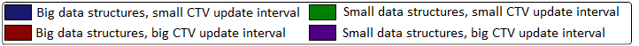

```python
from IPython.display import Image
Image(filename='../Results/Other/graphdescription.png')
```

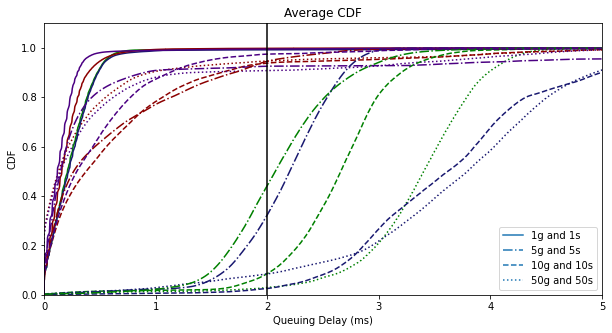

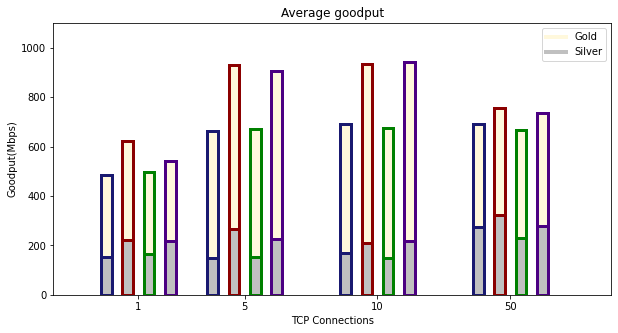

```python
name = "Overview_r2ms"
save = False
Plots = StartPlot(name, save)
```

```
Average delay 0.487002 ms
Average throughput for Gold flows: 72.7901
Average throughput for Silver flows: 21.6065
```

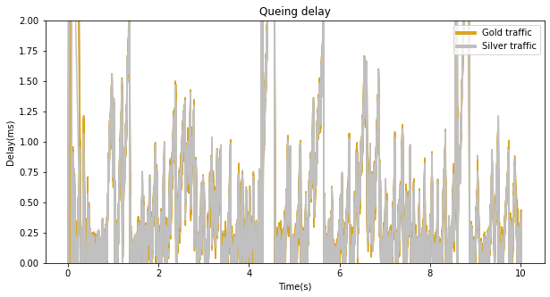

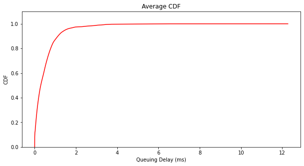

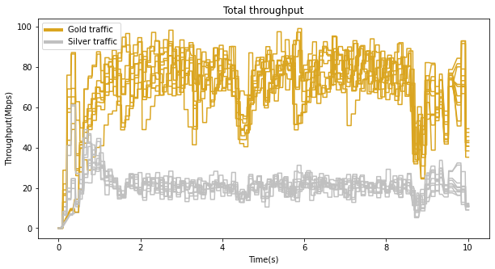

```python
name = "Overview_r2ms_10_m8_c10_t5ms"
save = False
Plots = StartPlot(name, save)
```

### Reference delay 200Mus

**Name: Overview_r200Mus**

- Gold and Silver static connections and queuing delay CDF.
  - 1 of each: Overview_r200Mus_1
    - Overview_r200Mus_1_m8_c10_t1Mus
    - Overview_r200Mus_1_m8_c10_t5ms
    - Overview_r200Mus_1_m13_c14_t1Mus
    - Overview_r200Mus_1_m13_c14_t5ms
  - 5 of each: Overview_r200Mus_C_5
    - Overview_r200Mus_5_m8_c10_t1Mus
    - Overview_r200Mus_5_m8_c10_t5ms
    - Overview_r200Mus_5_m13_c14_t1Mus
    - Overview_r200Mus_5_m13_c14_t5ms
  - 10 of each: Overview_r200Mus_C_10
    - Overview_r200Mus_10_m8_c10_t1Mus
    - Overview_r200Mus_10_m8_c10_t5ms
    - Overview_r200Mus_10_m13_c14_t1Mus
    - Overview_r200Mus_10_m13_c14_t5ms
  - 50 of each: Overview_r200Mus_C_50
    - Overview_r200Mus_50_m8_c10_t1Mus
    - Overview_r200Mus_50_m8_c10_t5ms
    - Overview_r200Mus_50_m13_c14_t1Mus
    - Overview_r200Mus_50_m13_c14_t5ms

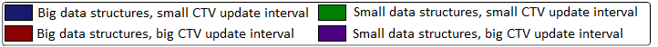

```python
from IPython.display import Image
Image(filename='../Results/Other/graphdescription.png')
```

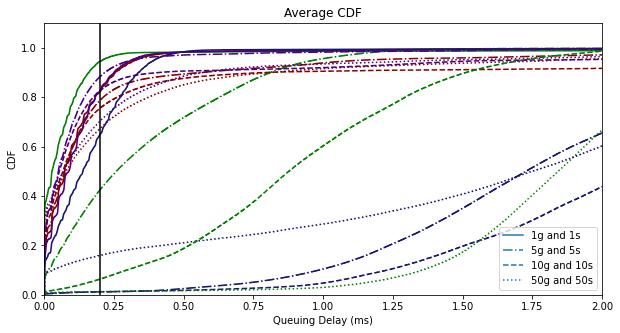

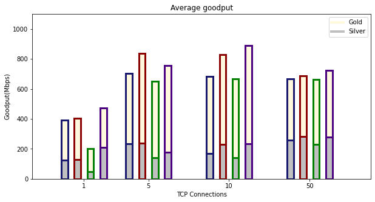

```python
name = "Overview_r200Mus"
save = False
Plots = StartPlot(name, save)
```

```
Average delay 1.17532 ms
Average throughput for Gold flows: 59.8468
Average throughput for Silver flows: 23.1194
```

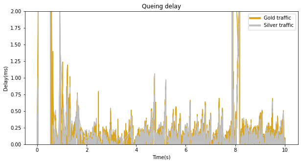

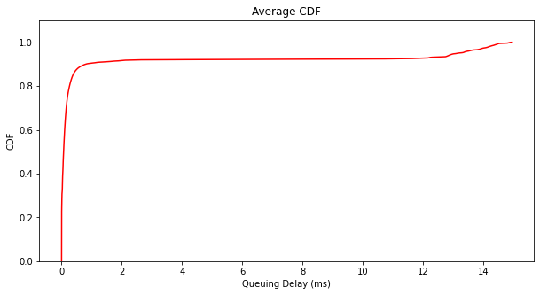

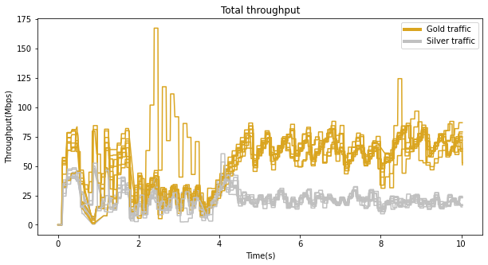

```python
name = "Overview_r200Mus_10_m13_c14_t5ms"
save = False
Plots = StartPlot(name, save)
```

## Evaluation

### 2. Evaluate queuing delay (over time and CDF), throughput over time using dynamic tests

#### 1. m = 8, c = 2^10, CTV update interval = 5ms, reference delay = 2ms.

Dynamic version:

- Name: "TEST_EvX_MC1_C5D1_P1_I4_T1_1"
- Starts with 5 flows of gold and 5 flows silver.
  - MC1: m = 8, c = 2^10.
  - C5D1: CTV update interval = 5ms, reference delay = 2ms.
  - P1: Port shaping 1gig.
  - I4: Add 5g and 5s each 10s
  - T1: Test time = 30s

Static version for comparison:

- Name: "Overview_r2ms_5_m8_c10_t5ms"

```
Average delay 0.523222 ms
Average throughput for all Gold flows: 84.3555
Average throughput for all Silver flows: 29.2984
```

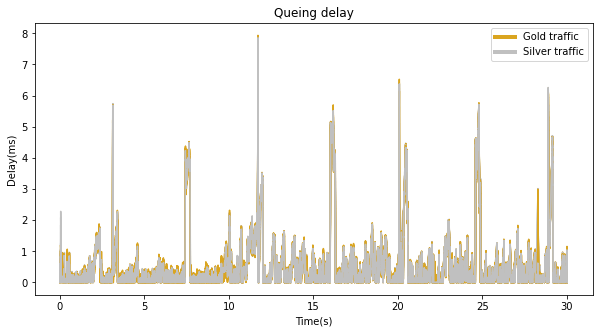

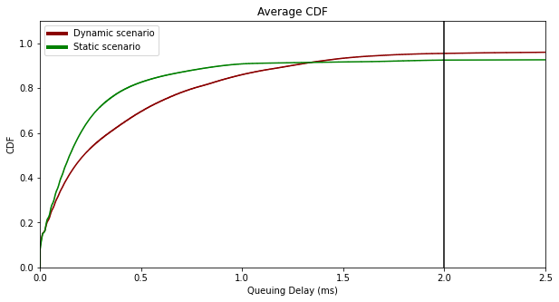

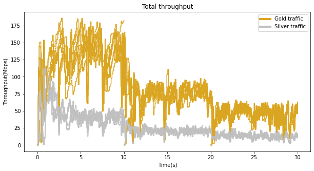

```python
name = ["TEST_EvX_MC1_C5D1_P1_I4_T1_1", "Overview_r2ms_5_m8_c10_t5ms"]
save = False
Plots = StartPlot(name, save, version = "Ev2")
```

#### 2. m = 8, c = 2^10, CTV update interval = 1µs, reference delay = 200µs.

Dynamic version:

- Name: "TEST_EvX_MC1_C2D2_P1_I4_T1_1"
- Starts with 5 flows of gold and 5 flows silver.
  - MC1: m = 8, c = 2^10.
  - C2D2: CTV update interval = 1µs, reference delay = 200µs.
  - P1: Port shaping 1gig.
  - I4: Add 5g and 5s each 10s
  - T1: Test time = 30s

Static version for comparison:

- Name: Overview_r200Mus_5_m8_c10_t1Mus

```
Average delay 0.948721 ms
Average throughput for all Gold flows: 64.2069
Average throughput for all Silver flows: 17.6239
```

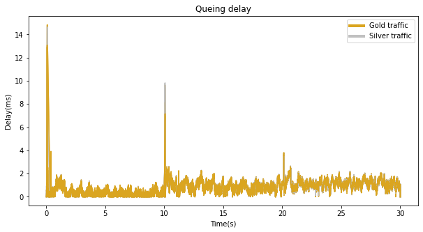

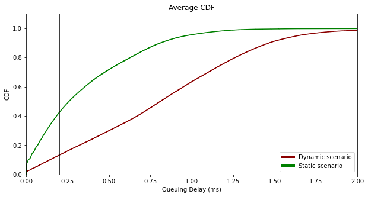

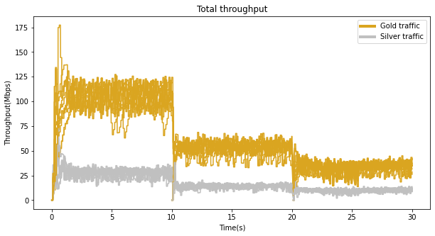

```python
name = ["TEST_EvX_MC1_C2D2_P1_I4_T1_1", "Overview_r200Mus_5_m8_c10_t1Mus"]
save = False
Plots = StartPlot(name, save, version = "Ev2")
```

## Evaluation

All tests can be found in Test_PacketInfo.txt

### 3. The following tests will evaluate queuing delay and flow fairness.

- The following assumptions are made:
  - m represents table size.
  - c represents counter size.
  - The ECDF update timer in the Control Plane is set to 0.
  - α is set to 0.3125 and β is set to 3.125, unless otherwise specified.

First a baseline test is introduced as test 1.

The settings for the baseline test is then slightly modified in test 2, 3, 4, 5 and 6.

Test 7 uses the setting used in the original PIE implementation.

Test 8 and 9 takes two settings from previous tests and adds 5 flows of each type each 10 seconds.

Test 10 and 11 uses the same settings as 8 and 9 but with c = 2^14 and to add 5 flows of each type each 1 second. The goal of test 10 and 11 is to add new flows faster than how often the ECDF is updated in the control plane, which for c = 2^14, is larger than 1s (as seen in "Read_recorded_registerValues"). Additionally, test 10 and 11 stops adding new flows after 30s.

Test 12 attempts to do the same as 10 and 11, but with c = 2^10, with 1 new flow added each 50ms for 10 seconds. Test 13 is run with an deactivates the AQM, as a point of reference.

### 1. Baseline test.

- Name: "TEST_EvX_MC1_C1D1_P1_I1_T1_1"
- Starts with 10 flows of gold and 10 flows silver.
  - MC1: m = 8, c = 2^10.
  - C1D1: CTV update interval = 10µs, reference delay = 2ms.
  - P1: Port shaping 1gig.
  - I1: No added flows.
  - T1: Test time = 30s

```
Average delay 2.23604 ms
Average throughput for all Gold flows: 67.0568
Average throughput for all Silver flows: 18.0243
```

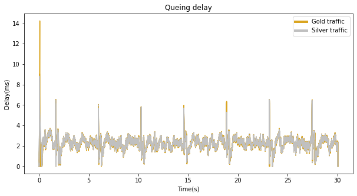

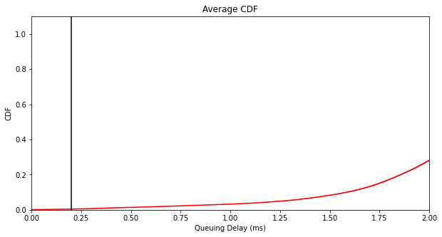

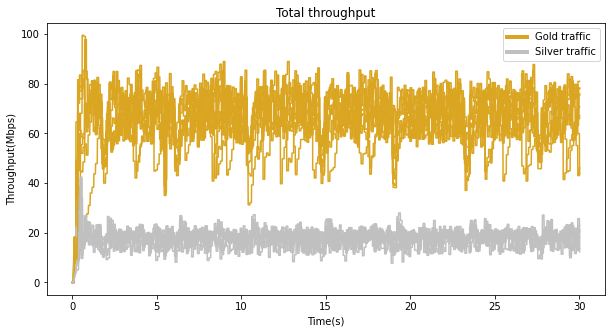

```python
name = "TEST_EvX_MC1_C1D1_P1_I1_T1_1"
save = False
Plots = StartPlot(name, save)
```

### 2. Baseline with:

##### Reference delay set to 200µs.

- Name: "TEST_EvX_MC1_C1D2_P1_I1_T1_1"
- Starts with 10 flows of gold and 10 flows silver.
  - MC1: m = 8, c = 2^10.
  - C1D2: CTV update interval = 10µs, reference delay = 200µs
  - P1: Port shaping 1gig.
  - I1: No added flows.
  - T1: Test time = 30s

```
Average delay 0.575631 ms
Average throughput for 10 Silver flows between 0-30s: 174 Mbps
Average throughput for 10 Gold flows between 0-30s: 660 Mbps
```

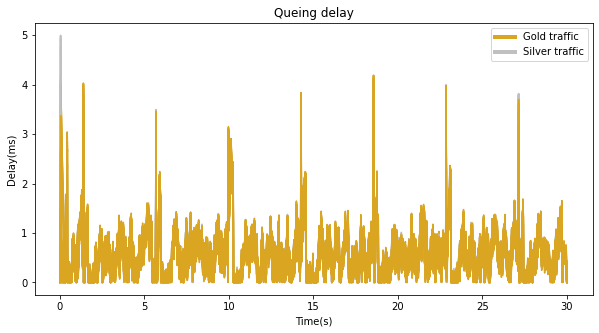

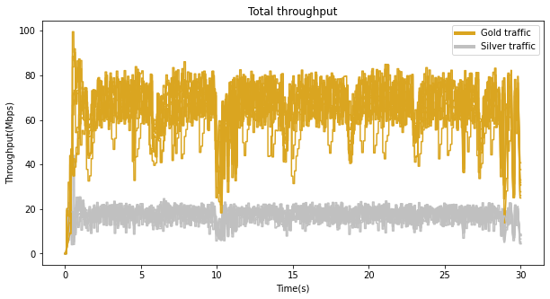

```python
name = "TEST_EvX_MC1_C1D2_P1_I1_T1_1"
save = False
Plots = StartPlot(name, save)
```

### 3. Baseline with:

#### CTV update interval set to 1µs

#### Reference delay set to 200µs

- Name: "TEST_EvX_MC1_C2D2_P1_I1_T1_1"
- Starts with 10 flows of gold and 10 flows silver.
  - MC1: m = 8, c = 2^10.
  - C2D2: CTV update interval = 1µs, reference delay = 200µs
  - P1: Port shaping 1gig.
  - I1: No added flows.
  - T1: Test time = 30s

```
Average delay 0.903125 ms
Average throughput for all Gold flows: 52.008
Average throughput for all Silver flows: 13.8209
```

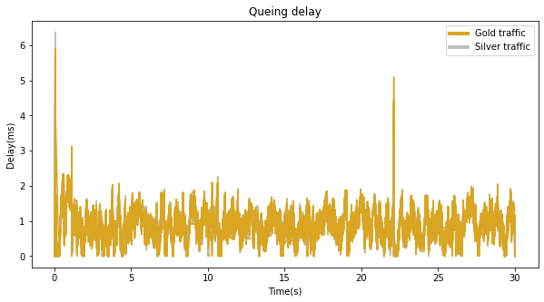

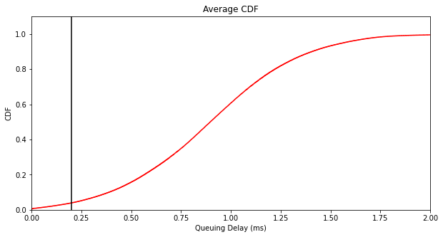

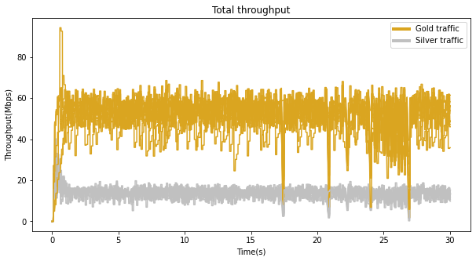

```python
name = "TEST_EvX_MC1_C2D2_P1_I1_T1_1"
save = False
Plots = StartPlot(name, save)
```

### 4. Baseline with:

#### CTV update interval set to 5ms (equal to half RTT).

- Name: "TEST_EvX_MC1_C5D1_P1_I1_T1_1"
- Starts with 10 flows of gold and 10 flows silver.
  - MC1: m = 8, c = 2^10.
  - C5D1: CTV update interval = 5ms, reference delay = 2ms.
  - P1: Port shaping 1gig.
  - I1: No added flows.
  - T1: Test time = 30s

```
Average delay 0.540945 ms
Average throughput for 10 Gold flows between 0-30s: 727 Mbps
Average throughput for 10 Silver flows between 0-30s: 205 Mbps
```

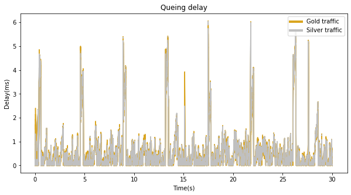

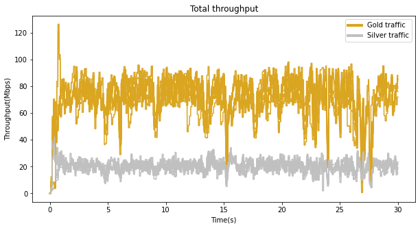

```python
name = "TEST_EvX_MC1_C5D1_P1_I1_T1_1"
save = False
Plots = StartPlot(name, save)
```

### 5. Baseline with:

#### CTV update interval set to 10ms (equal to RTT)

- Name: "TEST_EvX_MC1_C4D1_P1_I1_T1_1"
- Starts with 10 flows of gold and 10 flows silver.
  - MC1: m = 8, c = 2^10.
  - C4D1: CTV update interval = 10ms, reference delay = 2ms.
  - P1: Port shaping 1gig.
  - I1: No added flows.
  - T1: Test time = 30s

```
Average delay 0.85842 ms
Average throughput for 10 Gold flows between 0-30s: 685 Mbps
Average throughput for 10 Silver flows between 0-30s: 205 Mbps
```

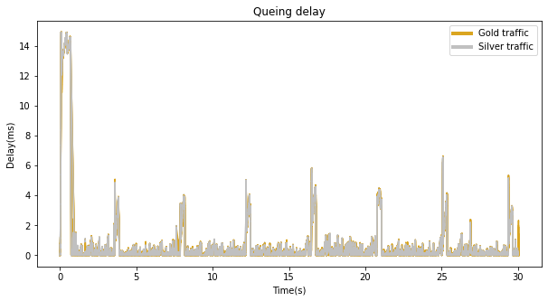

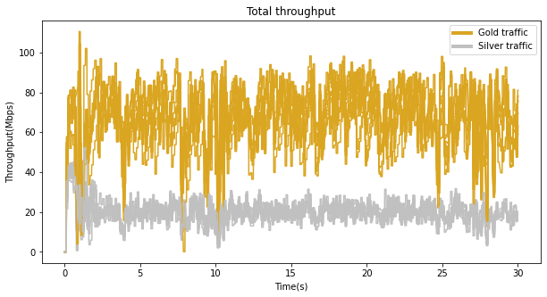

```python
name = "TEST_EvX_MC1_C4D1_P1_I1_T1_1"
save = False
Plots = StartPlot(name, save)
```